# INVESTIGATION OF CUSTOMER SUPPORT OFFERED IN THE UGANDAN TELECOM INDUSTRY - CUSTOMERS DATASET

## Table of Contents

- Introduction
- Data Wrangling Phase
- Data Cleaning Phase
- Data Exploration Phase
- Conclusion

## Introduction

This dataset is a collection of responses to my [survey](https://forms.gle/rEnU9mcDuduQQpr58) that seeks to investigate the perception of clients on existing customer support channels in the telecom industry in Uganda, as well as their views on proposed solutions to some of the challenges therein. It was accomplished as a partial requirement to attain my bachelor's degree in computer science at Makerere University, in 2023.

In this notebook, i'll be answering the following questions:

**Single variable (1d) questions:**

1. Which telecom service provider is considered the primary service provider by most respondents? go-to
2. On which social media platform do most respondents have an account? go-to
3. Which two social media channels are considered the best for sending a complaint to a telecom company? go-to
4. Which three features are considered most essential by customers in a customer support platform? go-to
5. Which factor is most important to customers when contacting customer support? go-to
6. How comfortable are customers with texting a chatbot when receiving customer support? go-to
7. How necessary is a platfrom dedicated to creating and managing customer support complaints to respondents? go-to

**Multivariable (2d...) questions:**

```python
# import libraries
import pandas as pd
import numpy as np
import matplotlib.pyplot as plt
plt.style.use('_mpl-gallery')
import seaborn as sns
%matplotlib inline
```

```python
# import customer_responses.csv
df = pd.read_csv('customer_survey.csv')
```

## DATA WRANGLING PHASE

```python
# shape of the dataset
df.shape
```

```
(135, 27)
```

```python
# columns of the dataset
columns_list = list(df.columns)

print('There are', len(columns_list), 'columns.')

for index, column_name in enumerate(columns_list):
    print("{}. {}".format(index + 1, column_name))
```

```
There are 27 columns.
1. Timestamp
2. What is your gender?
3. Which age range do you fall under?
4. What is your current marital status?
5. What is your highest level of education?
6. What is your current employment status?
7. Which of the following is your primary telecom service provider?
8. On which of the following social media platforms do you have an account?
9. Which three of these options do you consider to be the biggest (possible) challenges while receiving customer support from a telecom company
10. Which of these social media platforms would you consider to be the best channel for sending a complaint to a telecom company?
11. On a scale of 1 - 5, how comfortable are you texting a chatbot when trying to receive customer support?
12. On a scale of 1 to 5, how content or satisfied are you with the customer support offered by your primary telecom service provider (that you chose in the first section)?
13. On a scale 1 to 5, rate the average customer support offered by businesses in Uganda based on your experiences so far (complaints or requests for help)?
14. How essential to you would each of these features be in a customer support (care) platform? [should be a website]
15. How essential to you would each of these features be in a customer support (care) platform? [should be a mobile application]
16. How essential to you would each of these features be in a customer support (care) platform? [support live text chats with agents]
17. How essential to you would each of these features be in a customer support (care) platform? [support video call and screen sharing]
18. How essential to you would each of these features be in a customer support (care) platform? [support local languages]
19. How essential to you would each of these features be in a customer support (care) platform? [support sending images to customer support agent]
20. How essential to you would each of these features be in a customer support (care) platform? [offer a searchable self-help solutions knowledge base ]
21. How essential to you would each of these features be in a customer support (care) platform? [provide recommended solutions]
22. How essential to you would each of these features be in a customer support (care) platform? [show status on progress of my support request]
23. How essential to you would each of these features be in a customer support (care) platform? [schedule customer support appointments for later]
24. How essential to you would each of these features be in a customer support (care) platform? [rate and review customer support agents]
25. How essential to you would each of these features be in a customer support (care) platform? [have a discussion forum with fellow customers]
26. Which of these factors is most important to you when contacting customer support (customer care)?
27. How necessary do you think a mobile/web application dedicated to creating and managing your customer support complaints with various businesses, companies, institutions and government entities is to you?
```

```python
# data types of columns
df.dtypes
```

```
Timestamp                                                                                                                                                                                                       object
What is your gender?                                                                                                                                                                                            object
Which age range do you fall under?                                                                                                                                                                              object
What is your current marital status?                                                                                                                                                                            object
What is your highest level of education?                                                                                                                                                                        object
What is your current employment status?                                                                                                                                                                         object
Which of the following is your primary telecom service provider?                                                                                                                                                object
On which of the following social media platforms do you have an account?                                                                                                                                        object
Which three of these options do you consider to be the biggest (possible) challenges while receiving customer support from a telecom company                                                                    object
Which of these social media platforms would you consider to be the best channel for sending a complaint to a telecom company?                                                                                   object
On a scale of 1 - 5, how comfortable are you texting a chatbot when trying to receive customer support?                                                                                                          int64
On a scale of 1 to 5, how content or satisfied are you with the customer support offered by your primary telecom service provider (that you chose in the first section)?                                         int64
On a scale 1 to 5, rate the average customer support offered by businesses in Uganda based on your experiences so far (complaints or requests for help)?                                                         int64
How essential to you would each of these features be in a customer support (care) platform? [should be a website]                                                                                               object
How essential to you would each of these features be in a customer support (care) platform? [should be a mobile application]                                                                                    object
How essential to you would each of these features be in a customer support (care) platform? [support live text chats with agents]                                                                               object
How essential to you would each of these features be in a customer support (care) platform? [support video call and screen sharing]                                                                             object
How essential to you would each of these features be in a customer support (care) platform? [support local languages]                                                                                           object
How essential to you would each of these features be in a customer support (care) platform? [support sending images to customer support agent]                                                                  object
How essential to you would each of these features be in a customer support (care) platform? [offer a searchable self-help solutions knowledge base ]                                                            object
How essential to you would each of these features be in a customer support (care) platform? [provide recommended solutions]                                                                                     object
How essential to you would each of these features be in a customer support (care) platform? [show status on progress of my support request]                                                                     object
How essential to you would each of these features be in a customer support (care) platform? [schedule customer support appointments for later]                                                                  object
How essential to you would each of these features be in a customer support (care) platform? [rate and review customer support agents]                                                                           object
How essential to you would each of these features be in a customer support (care) platform? [have a discussion forum with fellow customers]                                                                     object
Which of these factors is most important to you when contacting customer support (customer care)?                                                                                                               object
How necessary do you think a mobile/web application dedicated to creating and managing your customer support complaints with various businesses, companies, institutions and government entities is to you?     object
dtype: object
```

```python
# unique values per column
df.nunique()
```

```
Timestamp                                                                                                                                                                                                       135
What is your gender?                                                                                                                                                                                              2
Which age range do you fall under?                                                                                                                                                                                4
What is your current marital status?                                                                                                                                                                              3
What is your highest level of education?                                                                                                                                                                          4
What is your current employment status?                                                                                                                                                                           8
Which of the following is your primary telecom service provider?                                                                                                                                                  4
On which of the following social media platforms do you have an account?                                                                                                                                         16
Which three of these options do you consider to be the biggest (possible) challenges while receiving customer support from a telecom company                                                                     17
Which of these social media platforms would you consider to be the best channel for sending a complaint to a telecom company?                                                                                    11
On a scale of 1 - 5, how comfortable are you texting a chatbot when trying to receive customer support?                                                                                                           5
On a scale of 1 to 5, how content or satisfied are you with the customer support offered by your primary telecom service provider (that you chose in the first section)?                                          5
On a scale 1 to 5, rate the average customer support offered by businesses in Uganda based on your experiences so far (complaints or requests for help)?                                                          5
How essential to you would each of these features be in a customer support (care) platform? [should be a website]                                                                                                 4
How essential to you would each of these features be in a customer support (care) platform? [should be a mobile application]                                                                                      4
How essential to you would each of these features be in a customer support (care) platform? [support live text chats with agents]                                                                                 4
How essential to you would each of these features be in a customer support (care) platform? [support video call and screen sharing]                                                                               4
How essential to you would each of these features be in a customer support (care) platform? [support local languages]                                                                                             4
How essential to you would each of these features be in a customer support (care) platform? [support sending images to customer support agent]                                                                    4
How essential to you would each of these features be in a customer support (care) platform? [offer a searchable self-help solutions knowledge base ]                                                              4
How essential to you would each of these features be in a customer support (care) platform? [provide recommended solutions]                                                                                       4
How essential to you would each of these features be in a customer support (care) platform? [show status on progress of my support request]                                                                       4
How essential to you would each of these features be in a customer support (care) platform? [schedule customer support appointments for later]                                                                    4
How essential to you would each of these features be in a customer support (care) platform? [rate and review customer support agents]                                                                             4
How essential to you would each of these features be in a customer support (care) platform? [have a discussion forum with fellow customers]                                                                       4
Which of these factors is most important to you when contacting customer support (customer care)?                                                                                                                 3
How necessary do you think a mobile/web application dedicated to creating and managing your customer support complaints with various businesses, companies, institutions and government entities is to you?       3
dtype: int64
```

```python
# head of the dataset (first three rows)
df.head(3)
```

|  | Timestamp | What is your gender? | Which age range do you fall under? | What is your current marital status? | What is your highest level of education? | What is your current employment status? | Which of the following is your primary telecom service provider? | On which of the following social media platforms do you have an account? | Which three of these options do you consider to be the biggest (possible) challenges while receiving customer support from a telecom company | Which of these social media platforms would you consider to be the best channel for sending a complaint to a telecom company? | ... | How essential to you would each of these features be in a customer support (care) platform? [support local languages] | How essential to you would each of these features be in a customer support (care) platform? [support sending images to customer support agent] | How essential to you would each of these features be in a customer support (care) platform? [offer a searchable self-help solutions knowledge base ] | How essential to you would each of these features be in a customer support (care) platform? [provide recommended solutions] | How essential to you would each of these features be in a customer support (care) platform? [show status on progress of my support request] | How essential to you would each of these features be in a customer support (care) platform? [schedule customer support appointments for later] | How essential to you would each of these features be in a customer support (care) platform? [rate and review customer support agents] | How essential to you would each of these features be in a customer support (care) platform? [have a discussion forum with fellow customers] | Which of these factors is most important to you when contacting customer support (customer care)? | How necessary do you think a mobile/web application dedicated to creating and managing your customer support complaints with various businesses, companies, institutions and government entities is to y… |
| --- | --- | --- | --- | --- | --- | --- | --- | --- | --- | --- | --- | --- | --- | --- | --- | --- | --- | --- | --- | --- | --- |
| 0 | 2022/08/18 10:40:07 am GMT+3 | Male | 20 years - 35 years | Cohabiting | Undergraduate | Student | MTN | Email;WhatsApp;Twitter;Facebook;Telegram | Many steps have to be followed to talk to a cu... | Twitter | ... | very essential | very essential | essential | very essential | very essential | very essential | essential | essential | Speed at which my issue is sorted. | Very necessary |
| 1 | 2022/08/18 10:47:47 am GMT+3 | Male | 20 years - 35 years | Single | Undergraduate | Student | AIRTEL | Email;WhatsApp;Twitter;Telegram | Many steps have to be followed to talk to a cu... | WhatsApp | ... | very essential | essential | not essential | not essential | essential | not essential | essential | I am not sure | Speed at which my issue is sorted. | Very necessary |
| 2 | 2022/08/18 10:58:09 am GMT+3 | Male | 20 years - 35 years | Single | Undergraduate | Student | AIRTEL | Email;WhatsApp;Twitter;Facebook;Telegram | Many steps have to be followed to talk to a cu... | Twitter | ... | very essential | very essential | very essential | very essential | very essential | very essential | essential | very essential | Speed at which my issue is sorted. | Very necessary |

3 rows × 27 columns

```python
# tail of the dataset (last three rows)
df.tail(3)
```

|  | Timestamp | What is your gender? | Which age range do you fall under? | What is your current marital status? | What is your highest level of education? | What is your current employment status? | Which of the following is your primary telecom service provider? | On which of the following social media platforms do you have an account? | Which three of these options do you consider to be the biggest (possible) challenges while receiving customer support from a telecom company | Which of these social media platforms would you consider to be the best channel for sending a complaint to a telecom company? | ... | How essential to you would each of these features be in a customer support (care) platform? [support local languages] | How essential to you would each of these features be in a customer support (care) platform? [support sending images to customer support agent] | How essential to you would each of these features be in a customer support (care) platform? [offer a searchable self-help solutions knowledge base ] | How essential to you would each of these features be in a customer support (care) platform? [provide recommended solutions] | How essential to you would each of these features be in a customer support (care) platform? [show status on progress of my support request] | How essential to you would each of these features be in a customer support (care) platform? [schedule customer support appointments for later] | How essential to you would each of these features be in a customer support (care) platform? [rate and review customer support agents] | How essential to you would each of these features be in a customer support (care) platform? [have a discussion forum with fellow customers] | Which of these factors is most important to you when contacting customer support (customer care)? | How necessary do you think a mobile/web application dedicated to creating and managing your customer support complaints with various businesses, companies, institutions and government entities is to y… |
| --- | --- | --- | --- | --- | --- | --- | --- | --- | --- | --- | --- | --- | --- | --- | --- | --- | --- | --- | --- | --- | --- |
| 132 | 2022/08/19 10:28:57 am GMT+3 | Male | 20 years - 35 years | Single | Undergraduate | Student | MTN | Email;WhatsApp;Twitter;Facebook;Telegram | Many steps have to be followed to talk to a cu... | Twitter | ... | very essential | I am not sure | very essential | very essential | very essential | essential | very essential | essential | Speed at which my issue is sorted. | I am not sure |
| 133 | 2022/08/19 10:33:41 am GMT+3 | Male | 20 years - 35 years | Single | Undergraduate | Student | MTN | Email;WhatsApp;Facebook;Telegram | Many steps have to be followed to talk to a cu... | WhatsApp | ... | not essential | essential | not essential | essential | essential | essential | essential | not essential | Speed at which my issue is sorted. | I am not sure |
| 134 | 2022/08/19 10:43:59 am GMT+3 | Male | 20 years - 35 years | Single | Undergraduate | Self employed | AIRTEL | Email;WhatsApp;Twitter;Facebook;Telegram | Many steps have to be followed to talk to a cu... | Twitter | ... | essential | not essential | not essential | essential | essential | not essential | not essential | not essential | Speed at which my issue is sorted. | Very necessary |

3 rows × 27 columns

```python
# statistical description of the dataset
df.describe()
```

|  | On a scale of 1 - 5, how comfortable are you texting a chatbot when trying to receive customer support? | On a scale of 1 to 5, how content or satisfied are you with the customer support offered by your primary telecom service provider (that you chose in the first section)? | On a scale 1 to 5, rate the average customer support offered by businesses in Uganda based on your experiences so far (complaints or requests for help)? |
| --- | --- | --- | --- |
| count | 135.000000 | 135.000000 | 135.000000 |
| mean | 2.992593 | 3.333333 | 2.970370 |
| std | 1.224722 | 0.977356 | 0.809835 |
| min | 1.000000 | 1.000000 | 1.000000 |
| 25% | 2.000000 | 3.000000 | 3.000000 |
| 50% | 3.000000 | 3.000000 | 3.000000 |
| 75% | 4.000000 | 4.000000 | 3.000000 |
| max | 5.000000 | 5.000000 | 5.000000 |

```python
# informative description of the dataset
df.info()
```

```
<class 'pandas.core.frame.DataFrame'>
RangeIndex: 135 entries, 0 to 134
Data columns (total 27 columns):
 #   Column                                                                                                                                                                                                        Non-Null Count  Dtype
---  ------                                                                                                                                                                                                        --------------  -----
 0   Timestamp                                                                                                                                                                                                     135 non-null    object
 1   What is your gender?                                                                                                                                                                                          135 non-null    object
 2   Which age range do you fall under?                                                                                                                                                                            135 non-null    object
 3   What is your current marital status?                                                                                                                                                                          135 non-null    object
 4   What is your highest level of education?                                                                                                                                                                      135 non-null    object
 5   What is your current employment status?                                                                                                                                                                       135 non-null    object
 6   Which of the following is your primary telecom service provider?                                                                                                                                              135 non-null    object
 7   On which of the following social media platforms do you have an account?                                                                                                                                      135 non-null    object
 8   Which three of these options do you consider to be the biggest (possible) challenges while receiving customer support from a telecom company                                                                  135 non-null    object
 9   Which of these social media platforms would you consider to be the best channel for sending a complaint to a telecom company?                                                                                 135 non-null    object
```

[output cut: 19 more lines]

## DATA CLEANING PHASE

```python
# check for duplicated rows
df.duplicated().sum()
```

```
0
```

```python
# check for and handle null values
df.isnull().sum()
```

```
Timestamp                                                                                                                                                                                                       0
What is your gender?                                                                                                                                                                                            0
Which age range do you fall under?                                                                                                                                                                              0
What is your current marital status?                                                                                                                                                                            0
What is your highest level of education?                                                                                                                                                                        0
What is your current employment status?                                                                                                                                                                         0
Which of the following is your primary telecom service provider?                                                                                                                                                0
On which of the following social media platforms do you have an account?                                                                                                                                        0
Which three of these options do you consider to be the biggest (possible) challenges while receiving customer support from a telecom company                                                                    0
Which of these social media platforms would you consider to be the best channel for sending a complaint to a telecom company?                                                                                   0
On a scale of 1 - 5, how comfortable are you texting a chatbot when trying to receive customer support?                                                                                                         0
On a scale of 1 to 5, how content or satisfied are you with the customer support offered by your primary telecom service provider (that you chose in the first section)?                                        0
On a scale 1 to 5, rate the average customer support offered by businesses in Uganda based on your experiences so far (complaints or requests for help)?                                                        0
How essential to you would each of these features be in a customer support (care) platform? [should be a website]                                                                                               0
How essential to you would each of these features be in a customer support (care) platform? [should be a mobile application]                                                                                    0
How essential to you would each of these features be in a customer support (care) platform? [support live text chats with agents]                                                                               0
How essential to you would each of these features be in a customer support (care) platform? [support video call and screen sharing]                                                                             0
How essential to you would each of these features be in a customer support (care) platform? [support local languages]                                                                                           0
How essential to you would each of these features be in a customer support (care) platform? [support sending images to customer support agent]                                                                  0
How essential to you would each of these features be in a customer support (care) platform? [offer a searchable self-help solutions knowledge base ]                                                            0
How essential to you would each of these features be in a customer support (care) platform? [provide recommended solutions]                                                                                     0
How essential to you would each of these features be in a customer support (care) platform? [show status on progress of my support request]                                                                     0
How essential to you would each of these features be in a customer support (care) platform? [schedule customer support appointments for later]                                                                  0
How essential to you would each of these features be in a customer support (care) platform? [rate and review customer support agents]                                                                           0
How essential to you would each of these features be in a customer support (care) platform? [have a discussion forum with fellow customers]                                                                     0
Which of these factors is most important to you when contacting customer support (customer care)?                                                                                                               0
How necessary do you think a mobile/web application dedicated to creating and managing your customer support complaints with various businesses, companies, institutions and government entities is to you?     0
dtype: int64
```

```python
# create index column - id
df['id'] = range(1, len(df) + 1)
df = df.set_index('id')
```

```python
# drop unecessary columns
df = df.drop('Timestamp', axis=1)
df
```

| id | What is your gender? | Which age range do you fall under? | What is your current marital status? | What is your highest level of education? | What is your current employment status? | Which of the following is your primary telecom service provider? | On which of the following social media platforms do you have an account? | Which three of these options do you consider to be the biggest (possible) challenges while receiving customer support from a telecom company | Which of these social media platforms would you consider to be the best channel for sending a complaint to a telecom company? | On a scale of 1 - 5, how comfortable are you texting a chatbot when trying to receive customer support? | ... | How essential to you would each of these features be in a customer support (care) platform? [support local languages] | How essential to you would each of these features be in a customer support (care) platform? [support sending images to customer support agent] | How essential to you would each of these features be in a customer support (care) platform? [offer a searchable self-help solutions knowledge base ] | How essential to you would each of these features be in a customer support (care) platform? [provide recommended solutions] | How essential to you would each of these features be in a customer support (care) platform? [show status on progress of my support request] | How essential to you would each of these features be in a customer support (care) platform? [schedule customer support appointments for later] | How essential to you would each of these features be in a customer support (care) platform? [rate and review customer support agents] | How essential to you would each of these features be in a customer support (care) platform? [have a discussion forum with fellow customers] | Which of these factors is most important to you when contacting customer support (customer care)? | How necessary do you think a mobile/web application dedicated to creating and managing your customer support complaints with various businesses, companies, institutions and government entities is to y… |
| --- | --- | --- | --- | --- | --- | --- | --- | --- | --- | --- | --- | --- | --- | --- | --- | --- | --- | --- | --- | --- | --- |
| 1 | Male | 20 years - 35 years | Cohabiting | Undergraduate | Student | MTN | Email;WhatsApp;Twitter;Facebook;Telegram | Many steps have to be followed to talk to a cu... | Twitter | 4 | ... | very essential | very essential | essential | very essential | very essential | very essential | essential | essential | Speed at which my issue is sorted. | Very necessary |
| 2 | Male | 20 years - 35 years | Single | Undergraduate | Student | AIRTEL | Email;WhatsApp;Twitter;Telegram | Many steps have to be followed to talk to a cu... | WhatsApp | 1 | ... | very essential | essential | not essential | not essential | essential | not essential | essential | I am not sure | Speed at which my issue is sorted. | Very necessary |
| 3 | Male | 20 years - 35 years | Single | Undergraduate | Student | AIRTEL | Email;WhatsApp;Twitter;Facebook;Telegram | Many steps have to be followed to talk to a cu... | Twitter | 5 | ... | very essential | very essential | very essential | very essential | very essential | very essential | essential | very essential | Speed at which my issue is sorted. | Very necessary |
| 4 | Male | 20 years - 35 years | Single | Undergraduate | Self employed | AIRTEL | Email;WhatsApp;Twitter;Facebook;Telegram | Many steps have to be followed to talk to a cu... | Email | 1 | ... | very essential | not essential | very essential | very essential | very essential | not essential | not essential | not essential | How easy it is for me to have my issue sorted. | Very necessary |
| 5 | Female | 20 years - 35 years | Single | Secondary school | Student | MTN | Email;WhatsApp;Twitter;Facebook;Telegram | Many steps have to be followed to talk to a cu... | WhatsApp | 5 | ... | very essential | not essential | very essential | very essential | very essential | very essential | very essential | very essential | Speed at which my issue is sorted. | Not necessary at all |
| ... | ... | ... | ... | ... | ... | ... | ... | ... | ... | ... | ... | ... | ... | ... | ... | ... | ... | ... | ... | ... | ... |
| 131 | Male | 20 years - 35 years | Single | Secondary school | Student | AIRTEL | Email;WhatsApp;Twitter;Facebook;Telegram | Many steps have to be followed to talk to a cu... | WhatsApp | 4 | ... | very essential | very essential | very essential | very essential | very essential | essential | essential | essential | Speed at which my issue is sorted. | Very necessary |
| 132 | Male | 20 years - 35 years | Single | Secondary school | Student | MTN | Email;WhatsApp;Twitter;Facebook;Telegram | Many steps have to be followed to talk to a cu... | Twitter | 2 | ... | very essential | not essential | very essential | essential | very essential | essential | very essential | not essential | Ability to have my issue sorted on my own (wit... | Very necessary |
| 133 | Male | 20 years - 35 years | Single | Undergraduate | Student | MTN | Email;WhatsApp;Twitter;Facebook;Telegram | Many steps have to be followed to talk to a cu... | Twitter | 3 | ... | very essential | I am not sure | very essential | very essential | very essential | essential | very essential | essential | Speed at which my issue is sorted. | I am not sure |
| 134 | Male | 20 years - 35 years | Single | Undergraduate | Student | MTN | Email;WhatsApp;Facebook;Telegram | Many steps have to be followed to talk to a cu... | WhatsApp | 4 | ... | not essential | essential | not essential | essential | essential | essential | essential | not essential | Speed at which my issue is sorted. | I am not sure |
| 135 | Male | 20 years - 35 years | Single | Undergraduate | Self employed | AIRTEL | Email;WhatsApp;Twitter;Facebook;Telegram | Many steps have to be followed to talk to a cu... | Twitter | 1 | ... | essential | not essential | not essential | essential | essential | not essential | not essential | not essential | Speed at which my issue is sorted. | Very necessary |

135 rows × 26 columns

```python
# give columns appropriate names
new_column_names = [
    "gender",
    "age_range",
    "marital_status",
    "education_level",
    "employment_status",
    "main_telecom",
    "social_channels",
    "challenges_in_support",
    "best_social_for_support",
    "comfort_with_chatbot",
    "csat_with_main_telecom_support",
    "ug_support_rating",
    "website_feat",
    "mobile_app_feat",
    "text_chat_feat",
    "video_and_screen_share_feat",
    "local_languages_feat",
    "send_images_feat",
    "searchable_self_help_feat",
    "recommended_solutions_feat",
    "issue_progress_status_feat",
    "schedule_support_feat",
    "rate_and_review_agent_feat",
    "discussion_forum_feat",
    "important_factor_in_support",
    "necessity_of_app_for_support"
]
df = df.set_axis(new_column_names, axis=1, inplace=False)
```

```python
# clean column values

# clean gender column
df = df.replace({'Male': 'male', 'Female': 'female'})

# clean age column
df = df.replace({'below 19 years': '<19', '20 years - 35 years': '20-35', '35 years - 45 years': '35-40', 'above 45 years': '>45' })

# clean marital status column
df = df.replace({'Cohabiting': 'single', 'Single': 'single', 'Married': 'married'})

# clean education level column
df = df.replace({'Undergraduate': 'undergraduate', 'Secondary school': 'secondary', 'Vocational college': 'vocational', 'Post graduate and above': 'postgraduate'})

# clean employment status column
df = df.replace({'Student': 'student', 'Self employed': 'self employed', "Unemployed, looking for work": 'unemployed', 'Employed on a salary': 'salary earner', 'Retired': 'retired', 'Volunteering ': 'unemployed', 'Student & self employed ': 'self employed', 'Confidential': 'unknown_status'})

# clean main telecom column
df = df.replace({'MTN': 'Mtn', 'AIRTEL': 'Airtel', 'Lyca mobile': 'Lycamobile', 'Lyca Mobile': 'Lycamobile'})

# clean social channels column
unclean_socials = list(df['social_channels'])
clean_socials = []

for social_group in list(df['social_channels']):
    clean_socials.append(social_group.lower().replace(';', ' | '))

df = df.replace(unclean_socials, clean_socials)

# clean challenges in support column
unclean_challenges = list(df['challenges_in_support'])
clean_challenges = []

for challenges_group in list(df['challenges_in_support']):
    clean_challenges = challenges_group.lower().replace(';', ' | ')
    clean_challenges = clean_challenges.replace('many steps have to be followed to talk to a customer care agent.', 'many steps to talk to an agent')
    clean_challenges = clean_challenges.replace('no/late responses to my customer support complaints on social media.', 'no or late responses to tickets')
    clean_challenges = clean_challenges.replace('connected to an agent with low technical knowledge needed to handle my issue.', 'connected to agent with low technical knowledge')
    clean_challenges = clean_challenges.replace('no/low availability of customer support agents late in the night.', 'no or few agents availabe at night')
    clean_challenges = clean_challenges.replace('no/low availability of customer support agents over the weekends.', 'no or few agents availabe on weekends')
    unclean_challenges.append(clean_challenges)

# clean best social for support column
df = df.replace({'Calls': 'call', 'Phone call': 'call', 'call': 'call', 'Messages': 'sms', 'Feedback message ': 'sms', 'Facebook': 'facebook', 'Phone call ': 'call'})

# clean feat columns
df = df.replace({'I am not sure': 'not sure'})
df['website_feat'].unique()

# clean important factor in support column
df = df.replace({'Speed at which my issue is sorted.': 'speed', 'How easy it is for me to have my issue sorted.': 'ease', 'Ability to have my issue sorted on my own (without having to talk to an agent or someone)': 'self service'})

# clean necessity of app for support column
df = df.replace({'Very necessary': 'very necessary', 'Not necessary at all': 'not necessary', 'not sure': 'not sure'})

df
```

| id | gender | age_range | marital_status | education_level | employment_status | main_telecom | social_channels | challenges_in_support | best_social_for_support | comfort_with_chatbot | ... | local_languages_feat | send_images_feat | searchable_self_help_feat | recommended_solutions_feat | issue_progress_status_feat | schedule_support_feat | rate_and_review_agent_feat | discussion_forum_feat | important_factor_in_support | necessity_of_app_for_support |
| --- | --- | --- | --- | --- | --- | --- | --- | --- | --- | --- | --- | --- | --- | --- | --- | --- | --- | --- | --- | --- | --- |
| 1 | male | 20-35 | single | undergraduate | student | Mtn | email \| whatsapp \| twitter \| facebook \| telegram | Many steps have to be followed to talk to a cu... | twitter | 4 | ... | very essential | very essential | essential | very essential | very essential | very essential | essential | essential | speed | very necessary |
| 2 | male | 20-35 | single | undergraduate | student | Airtel | email \| whatsapp \| twitter \| telegram | Many steps have to be followed to talk to a cu... | whatsapp | 1 | ... | very essential | essential | not essential | not essential | essential | not essential | essential | not sure | speed | very necessary |
| 3 | male | 20-35 | single | undergraduate | student | Airtel | email \| whatsapp \| twitter \| facebook \| telegram | Many steps have to be followed to talk to a cu... | twitter | 5 | ... | very essential | very essential | very essential | very essential | very essential | very essential | essential | very essential | speed | very necessary |
| 4 | male | 20-35 | single | undergraduate | self employed | Airtel | email \| whatsapp \| twitter \| facebook \| telegram | Many steps have to be followed to talk to a cu... | email | 1 | ... | very essential | not essential | very essential | very essential | very essential | not essential | not essential | not essential | ease | very necessary |
| 5 | female | 20-35 | single | secondary | student | Mtn | email \| whatsapp \| twitter \| facebook \| telegram | Many steps have to be followed to talk to a cu... | whatsapp | 5 | ... | very essential | not essential | very essential | very essential | very essential | very essential | very essential | very essential | speed | not necessary |
| ... | ... | ... | ... | ... | ... | ... | ... | ... | ... | ... | ... | ... | ... | ... | ... | ... | ... | ... | ... | ... | ... |
| 131 | male | 20-35 | single | secondary | student | Airtel | email \| whatsapp \| twitter \| facebook \| telegram | Many steps have to be followed to talk to a cu... | whatsapp | 4 | ... | very essential | very essential | very essential | very essential | very essential | essential | essential | essential | speed | very necessary |
| 132 | male | 20-35 | single | secondary | student | Mtn | email \| whatsapp \| twitter \| facebook \| telegram | Many steps have to be followed to talk to a cu... | twitter | 2 | ... | very essential | not essential | very essential | essential | very essential | essential | very essential | not essential | self service | very necessary |
| 133 | male | 20-35 | single | undergraduate | student | Mtn | email \| whatsapp \| twitter \| facebook \| telegram | Many steps have to be followed to talk to a cu... | twitter | 3 | ... | very essential | not sure | very essential | very essential | very essential | essential | very essential | essential | speed | not sure |
| 134 | male | 20-35 | single | undergraduate | student | Mtn | email \| whatsapp \| facebook \| telegram | Many steps have to be followed to talk to a cu... | whatsapp | 4 | ... | not essential | essential | not essential | essential | essential | essential | essential | not essential | speed | not sure |
| 135 | male | 20-35 | single | undergraduate | self employed | Airtel | email \| whatsapp \| twitter \| facebook \| telegram | Many steps have to be followed to talk to a cu... | twitter | 1 | ... | essential | not essential | not essential | essential | essential | not essential | not essential | not essential | speed | very necessary |

135 rows × 26 columns

```python
# convert columns to appropriate data types
```

## DATA EXPLORATION PHASE

### Reusable Functions:

```python
# reusables

# colors
base_color = '#273c75'
target_color = '#44bd32'

# Dataframe Subsets
feature_columns = ["website_feat", "mobile_app_feat", "text_chat_feat", "video_and_screen_share_feat", "local_languages_feat", "send_images_feat", "searchable_self_help_feat", "recommended_solutions_feat", "issue_progress_status_feat", "schedule_support_feat", "rate_and_review_agent_feat", "discussion_forum_feat"]

features_df = df[feature_columns]
```

### 1. Which telecom service provider is considered the primary service provider by most respondents?

```
(array([0, 1, 2]),
 [Text(0, 0, 'Airtel'), Text(1, 0, 'Mtn'), Text(2, 0, 'Lycamobile')])
```

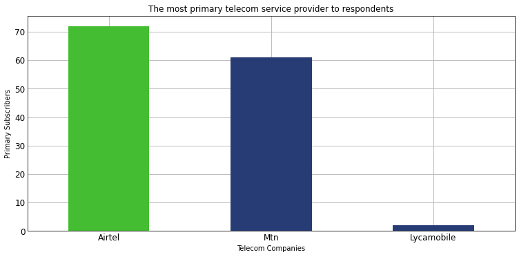

```python
main_telecom_count = pd.Series(df['main_telecom']).value_counts(ascending=False)

# plot a pie
main_telecom_count.plot(kind='bar', figsize=(10,5), fontsize=12, color=[target_color, base_color, base_color])
plt.title('The most primary telecom service provider to respondents')
plt.xlabel('Telecom Companies')
plt.ylabel('Primary Subscribers')
plt.xticks(rotation=0, horizontalalignment='center')
```

### 2. On which social media platform do most respondents have an account?

[output not shown]

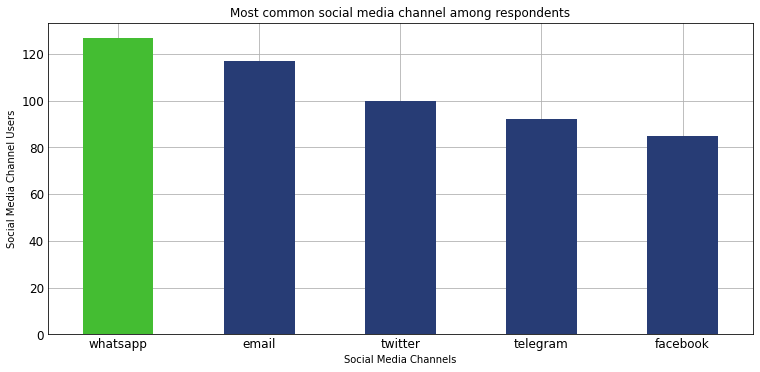

```python
total_social_channels_instances = df['social_channels'].str.cat(sep=' | ')
socials_channels_count = pd.Series(total_social_channels_instances.split(' | ')).value_counts(ascending=False)

# plot a pie
socials_channels_count.plot(kind='bar', figsize=(10,5), fontsize=12, color=[target_color, base_color, base_color, base_color, base_color])
plt.title('Most common social media channel among respondents')
plt.xlabel('Social Media Channels')
plt.ylabel('Social Media Channel Users')
plt.xticks(rotation=0, horizontalalignment='center')
```

### 3. Which two social media channels are considered the best for sending a complaint to a telecom company?

[output not shown]

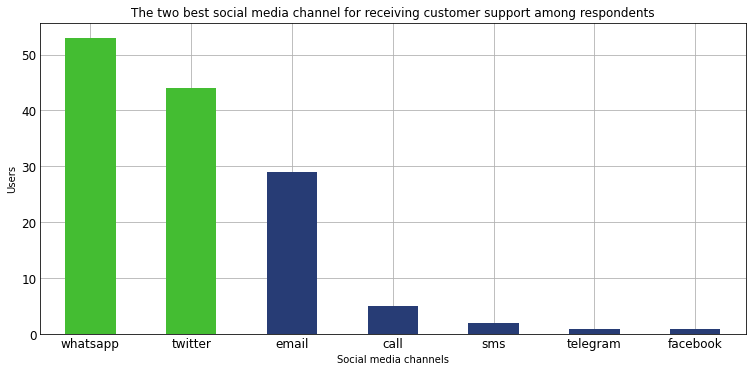

```python
main_telecom_count = pd.Series(df['best_social_for_support']).value_counts(ascending=False)

# plot a pie
main_telecom_count.plot(kind='bar', figsize=(10,5), fontsize=12, color=[target_color, target_color, base_color, base_color, base_color, base_color, base_color])
plt.title('The two best social media channel for receiving customer support among respondents')
plt.xlabel('Social media channels')
plt.ylabel('Users')
plt.xticks(rotation=0, horizontalalignment='center')
```

### 4. Which three features are considered most essential by customers in a customer support platform?

[output not shown]

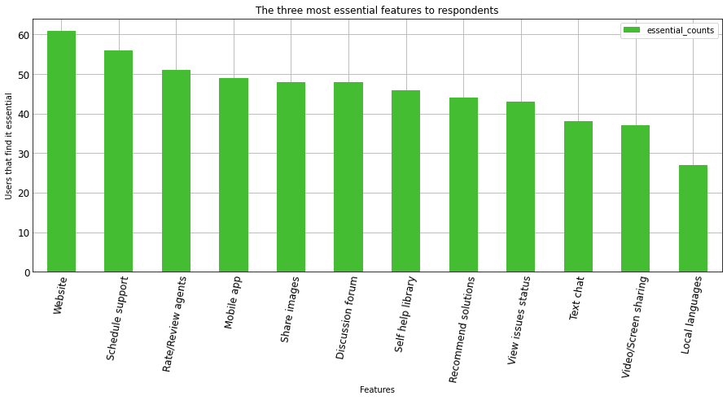

```python
feat_columns_labels = [
    "Website",
    "Mobile app",
    "Text chat",
    "Video/Screen sharing",
    "Local languages",
    "Share images",
    "Self help library",
    "Recommend solutions",
    "View issues status",
    "Schedule support",
    "Rate/Review agents",
    "Discussion forum"
]

essentials_counts_per_column = (features_df == 'essential').sum().to_numpy()

essential_counts_df = pd.DataFrame(data=essentials_counts_per_column, columns=['essential_counts'], index=feat_columns_labels).sort_values(by=['essential_counts'], ascending=False)
essential_counts_df.plot.bar(figsize=(12,5), fontsize=12, color=[target_color, base_color])

plt.title('The three most essential features to respondents')
plt.xlabel('Features')
plt.ylabel('Users that find it essential')
plt.xticks(rotation=80, horizontalalignment='center')
```

### 5. Which factor is most important to customers when contacting customer support?

```
(array([0, 1, 2]),
 [Text(0, 0, 'speed'), Text(1, 0, 'ease'), Text(2, 0, 'self service')])
```

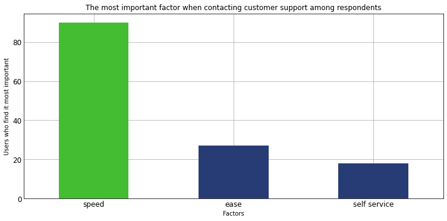

```python
important_factors_count = pd.Series(df['important_factor_in_support']).value_counts(ascending=False)

# plot a bar graph
important_factors_count.plot(kind='bar', figsize=(10,5), fontsize=12, color=[target_color, base_color, base_color])
plt.title('The most important factor when contacting customer support among respondents')
plt.xlabel('Factors')
plt.ylabel('Users who find it most important')
plt.xticks(rotation=0, horizontalalignment='center')
```

### 6. How comfortable are customers with texting a chatbot when receiving customer support?

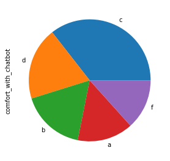

```python
pd.Series(df['comfort_with_chatbot'].replace({1:'a', 2:'b', 3:'c',4:'d', 5:'f'})).value_counts().plot(kind="pie")

# plt.title('The three most essential features to respondents')
# plt.xlabel('Features')
# plt.ylabel('Users that find it essential')
# plt.xticks(rotation=80, horizontalalignment='center')
```

### 7. How necessary is a platfrom dedicated to creating and managing customer support complaints to respondents?

[output not shown]

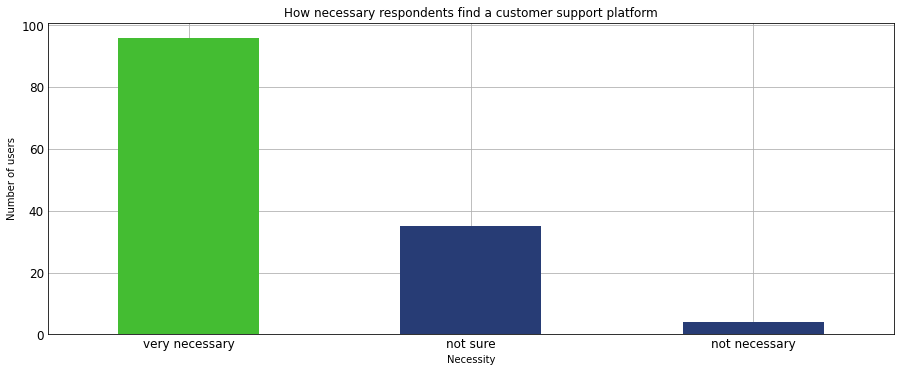

```python
necessity_of_support_platform_counts = pd.Series(df['necessity_of_app_for_support']).value_counts(ascending=False)

necessity_of_support_platform_counts.plot.bar(figsize=(12,5), fontsize=12, color=[target_color, base_color, base_color])

plt.title('How necessary respondents find a customer support platform')
plt.xlabel('Necessity')
plt.ylabel('Number of users')
plt.xticks(rotation=0, horizontalalignment='center')
```

## CONCLUSION

### Limitations:

### Resources used:

- Kaggle: *https://kaggle.com*
- Pandas Documentation: *https://pandas.pydata.org/docs/index.html*
- Seaborn API Reference: *https://seaborn.pydata.org/api.html*
- NumPy Documentation: *https://numpy.org/doc/stable/*
- "Correlation does not imply causation": *https://en.wikipedia.org/wiki/Correlation_does_not_imply_causation*